# Judging a Pitch by its Cover

Online Experiments (Replication Report)

Author

Affiliation

*blinded for review*

*blinded for review*

# 1 Introduction

For both our fictitious startups (Software: **PerkSouq**; Healthcare: **Brachytix**), we ran online experiments to determine how the (stated) likelihood to invest depends on the substantive quality and visual fluency of a pitch deck.

Specifically, we first ran a 2x2 between-subjects experiment for our software startup. To make sure that the instruction we used when measuring investment likelihood (“Based on the information at hand, what is the probability […]”) did not bias the results, we ran a replication of this first experiment with a modified instruction (“Based on the pitch deck, what is the probability […]”). To ensure generalizability across domains, we then ran the same experiment for our healthcare startup.

We ran all online experiments on [Qualtrics](https://www.qualtrics.com), hosted the pitch decks on [DocSend](https://www.docsend.com), and recruited the participants via [Prolific](https://www.prolific.co). For details, see the corresponding [AsPredicted](https://aspredicted.org) pre-registrations listed in Table 1.

Table 1: Overview Pre-Registrations

| Startup | Pre-Reg Date | AsPredicted # | Data Collection Start |
| --- | --- | --- | --- |
| Software startup | 28-11-2022 | [114380](https://aspredicted.org/7HH_PPC) | 30-11-2022 |
| Software startup (Replication) | 16-12-2022 | [116872](https://aspredicted.org/MT1_SNZ) | 17-12-2022 |
| Healthcare startup | 20-12-2022 | [117215](https://aspredicted.org/S7K_8ZX) | 21-12-2022 |

In what follows, we will give an overview of the results and robustness checks, followed by figures that summarize the results of the experiments. As this report is dynamically created with R and Quarto, we also report all code. However, for the sake of readability, the code itself is folded by default and only the results relevant for the questions at hand are shown.

```r
options(knitr.kable.NA = '')

# setup
library(here)
library(dplyr)
library(knitr)
library(ggplot2)
library(ggsignif)
library(ggtext)
library(patchwork)
library(kableExtra)
options(knitr.kable.NA = '',
        kable_styling_bootstrap_options = c("striped", "condensed", "responsive"))

# further packages that are loaded on demand are:
# - supernova
# - car
# - rstatix
# - forcats
# - weights
# - broom
# - scales
# - readr
# - tidyr
# - hrbrthemes
# - emmeans
# - grid


# Custom functions
#
# negate %in%
`%notin%` <- Negate(`%in%`)
#
# extract t-test results and Cohen's d and put the results together as a table
ttest_tbl <- function(formula, data, alternative = "two.sided", ...){
  # first, check for homogeneous group variances using Levene's test
  # --> if significant, use Welch's t-test (i.e., var.equal = FALSE)
  # note that we use a significance level of .05 for Levene's test, as pre-registered
  # we check if the p-value is not significant (i.e., p >= .05) and save this
  # information var.equal --> thus, we can use 'var.equal = var.equal' in the t-test
  var.equal <- car::leveneTest(formula, data = data)$`Pr(>F)`[1] >= .05
  # perform t-test
  tres <- t.test(formula, data = data, var.equal = var.equal, alternative = alternative)
  # extract Cohen's d
  dres <- rstatix::cohens_d(formula, data = data, var.equal = var.equal)
  # construct p-value
  pval <- ifelse(tres$p.value < .001, " &lt; .001", weights::rd(tres$p.value, 3))
  # extract dependent variable
  dv <- stringr::str_match(deparse(formula), '[^ ~]*')
  # construct return df
  df = data.frame(DV = NA, condition=rep(NA, 2), N = NA, Mean = NA, SD = NA, test_statistic = NA, p = NA, d = NA)
  # fill values
  df$DV[1] <- stringr::str_to_sentence(dres$`.y.`)
  df$condition <- c(dres$group1, dres$group2)
  df$N <- c(dres$n1, dres$n2)
  df$Mean <- weights::rd(aggregate(formula, data = data, FUN = mean)[,2], 2)
  df$SD <- weights::rd(aggregate(formula, data = data, FUN = sd)[,2], 3)
  df$test_statistic[1] <- paste0("t(",
                                 ifelse(var.equal == TRUE, tres$parameter,
                                        weights::rd(tres$parameter, 1)),
                                 ") = ",
                                 sprintf('%.2f', tres$statistic))
  df$p[1] <- pval
  df$d[1] <- weights::rd(dres$effsize, 2)
  return(df)
}
#
# extract ANOVA results including eta squared and put the results together as a table
# -Note: needs the supernova library installed
anova_tbl <- function(formula, data, type = 3, ...){
  # perform ANOVA
  d <- supernova::supernova(lm(as.formula(deparse(formula)), data = data), type = type)$tbl
  # check whether ANOVA is univariate or factorial
  univariate <- all(d$term %in% c("Model", "Error", "Total"))
  # get rows of interest
  if(univariate) {
    effect_rows <- d$term %notin% c("Error", "Total")
  } else {
    effect_rows <- d$term %notin% c("Model", "Error", "Total")
  }
  # extract key parameters
  effect <- d$term[effect_rows]
  MSE <- round(d$MS[effect_rows], 2)
  df <- d$df[effect_rows]
  df_res <- d$df[d$term == "Error"]
  statistic <- round(d$F[effect_rows], 2)
  pval <- ifelse(d$p[effect_rows] < .001, " &lt; .001", weights::rd(d$p[effect_rows], 3))
  eta <- ifelse(d$PRE[effect_rows] < .001, " &lt; .001", weights::rd(d$PRE[effect_rows], 3))
  # construct return df
  return(data.frame(effect, MSE, df, df_res, statistic, pval, eta))
}
# extract GLM results and put the results together as a table
glm_tbl <- function(model, coef_digits = 2, coef_bold = TRUE, p_threshold = 0.05, ...){
  # extract model parameters
  if("tobit" %in% class(model)){ # tobit model -> broom::tidy does not work
    res <- parameters::model_parameters(model)
    res <- res[c("Parameter", "Coefficient", "SE", "z", "p")]
    names(res) <- c("term", "estimate", "std.error", "statistic", "p.value")
    # res[] <- lapply(res, function(x) { attributes(x) <- NULL; x })
  } else {
    res <- broom::tidy(model)
  }
  pvals <- res$p.value
  res$estimate <- sprintf(paste0("%.", coef_digits, "f"), res$estimate)
  res$std.error <- sprintf("%.3f", res$std.error)
  res$statistic <- sprintf("%.2f", res$statistic)
  # format p value
  res$p.value <- ifelse(res$p.value < .001, " &lt; .001", weights::rd(res$p.value, 3))
  # make estimates bold if below critical p value
  if(coef_bold){
    res$estimate[pvals < p_threshold] <- paste0("<b>", res$estimate[pvals < p_threshold], "</b>")
    res$std.error[pvals < p_threshold] <- paste0("<b>", res$std.error[pvals < p_threshold], "</b>")
    res$statistic[pvals < p_threshold] <- paste0("<b>", res$statistic[pvals < p_threshold], "</b>")
    res$p.value[pvals < p_threshold] <- paste0("<b>", res$p.value[pvals < p_threshold], "</b>")
  }
  # bind R2 and Adj. R2 to model parameters
  r2 <- performance::r2(model) # extract R2
  end <- nrow(res) + seq_len(length(r2))
  res[end,"term"] <- names(r2)
  res[end,"estimate"] <- weights::rd(unlist(r2), digits = 3)
  # return result
  return(res)
}
```

# 2 Data preparation

For each experiment, the data preparation steps included cleaning and preprocessing the survey data (from Qualtrics), the demographic data (from Prolific), and the pitch deck tracking data (from DocSend), respectively. Next, the three data sources were merged, the pre-registered exclusions were performed, and the final, processed datasets were saved.

Note that in this report, we load the de-identified and anonymized datasets. Please consult the [online repository](https://researchbox.org/1836) for the code that processed the raw data.

```r
data_dir <- 'replication_reports/data'

# -----------------------------------------------------------------------------
# Software startup)
# -----------------------------------------------------------------------------
#
# Getting and preparing the datasets
#
# Survey data (Qualtrics)
d_qua <- readr::read_csv(here(data_dir, 'Study_2A_Software_Qualtrics.csv'))
# convert fluency and quality conditions into factors
d_qua$fluency_condition <- as.factor(d_qua$fluency_condition)
d_qua$quality_condition <- as.factor(d_qua$quality_condition)
# make variable names more coding friendly
d_qua_clean <- d_qua |>
  rename(duration_study = `Duration (in seconds)`, invest_prob = `invest_prob_1`,
         attention_check_text = attention_check_99_TEXT,
         IP_address = IPAddress) |>
  rename_at(vars(-ID, -PROLIFIC_PID, -IP_address), tolower)

# Demographic data (Prolific)
d_pro <- readr::read_csv(here(data_dir, 'Study_2A_Software_Prolific.csv'))
# make variable names more coding friendly
d_pro_clean <- d_pro |>
  rename(ethnicity = `Ethnicity simplified`, country = `Country of residence`,
         employment = `Employment status`,
         investment_types = `Types of investment`) |>
  rename_at(vars(-ID), tolower)
# remove age and sex from the data, since we explicitly asked this information
# in Qualtrics
d_pro_clean <- d_pro_clean |>
  select(-age, -sex)

# Pitch deck tracking data (DocSend)
d_doc <- readr::read_csv(here(data_dir, 'Study_2A_Software_DocSend.csv'))
# make variable names more coding friendly
d_doc_clean <- d_doc |>
  rename(duration_pitch_deck = duration,
         fluency_condition_docsend = fluency_condition,
         quality_condition_docsend = quality_condition) |>
  rename_at(vars(-ID), tolower)
# duration is recorded in Excel timestamp format,
# multiply by 86400 to convert to seconds
d_doc_clean$duration_pitch_deck <- d_doc_clean$duration_pitch_deck * 86400

# Merging the data
#
# merge Qualtrics and Prolific data
d_all <- merge(d_qua_clean, d_pro_clean, by = "ID", all = TRUE)
# merge the DocSend data
d_all <- merge(d_all, d_doc_clean, by = "ID", all = TRUE)
# to make typing easier, let's call our data d for now
d <- d_all
rm(d_all, d_doc, d_doc_clean, d_pro, d_pro_clean, d_qua, d_qua_clean)

# Exclusions
#
# participants did not give consent (or did not answer but closed survey or
# returned study submission)
d <- d |> filter(!(consent != "yes"))
# incomplete responses
d <- d |> tidyr::drop_na(!c(attention_check_text, investment_types, ethnicity,
                            country, nationality, employment, device))
# reported Prolific ID (ID) is different from actual Prolific ID
d <- d |> filter(!(ID != PROLIFIC_PID))
# duplicate Prolific IDs
d <- d |> group_by(ID) |> filter(!(n()>1)) |> ungroup()
# duplicate IP Address
d <- d |> group_by(IP_address) |> filter(!(n()>1)) |> ungroup()
# duration to complete survey more than 30 minutes
#   -Note: `duration_study` was measured in seconds
#          thus 30 minutes = 1800 seconds
d <- d |> filter(!(duration_study > 1800))
# pitch deck opened for less than 30 seconds or more than 30 minutes
d <- d |> filter(!(duration_pitch_deck < 30 | duration_pitch_deck > 1800))
# less than 50% of pitch deck slides were viewed
d <- d |> filter(!(completion < .5))
# participants failed attention check
#
# check which answers were given in text field
# unique(d$attention_check_text[d$attention_check == "Other"])
#
# versions of correct answers
str_attention_correct <- c(
  "I have read this text carefully",
  "I have read this text carefully \n\n",
  "I have read this carefully",
  "'I have read this text carefully '",
  "I have read the text carefully",
  "i have read this carefully",
  "I have read this text carefully.",
  "I have read this text carefully\n",
  "I have read this textbcarefully",
  "I have read this text carefully' below",
  "have read this text carefully"
)
# exclude participants with an answer not listed above
d <- d |> filter(!(attention_check != "Other" |
                 attention_check_text %notin% str_attention_correct))
# participants failed comprehension check
d <- d |> filter(!(comprehension_check != "HR technology"))
# condition from Qualtrics does not match DocSend condition
d <- d |> filter(fluency_condition == fluency_condition_docsend &
                   quality_condition == quality_condition_docsend)

# save processed data
d_sw <- d


# -----------------------------------------------------------------------------
# Software startup (replication)
# -----------------------------------------------------------------------------
#
# Getting and preparing the datasets
#
# Survey data (Qualtrics)
d_qua <- readr::read_csv(here(data_dir, 'Study_2B_Software_Replication_Qualtrics.csv'))
# convert fluency and quality conditions into factors
d_qua$fluency_condition <- as.factor(d_qua$fluency_condition)
d_qua$quality_condition <- as.factor(d_qua$quality_condition)
# make variable names more coding friendly
d_qua_clean <- d_qua |>
  rename(duration_study = `Duration (in seconds)`, invest_prob = `invest_prob_1`,
         fluency = `fluency_1`, attention_check_text = attention_check_99_TEXT,
         IP_address = IPAddress) |>
  rename_at(vars(-ID, -PROLIFIC_PID, -IP_address), tolower)

# Demographic data (Prolific)
d_pro <- readr::read_csv(here(data_dir, 'Study_2B_Software_Replication_Prolific.csv'))
# make variable names more coding friendly
d_pro_clean <- d_pro |>
  rename(ethnicity = `Ethnicity simplified`, country = `Country of residence`,
         employment = `Employment status`,
         investment_types = `Types of investment`) |>
  rename_at(vars(-ID), tolower)
# remove age and sex from the data, since we explicitly asked this information
# in Qualtrics
d_pro_clean <- d_pro_clean |>
  select(-age, -sex)

# Pitch deck tracking data (DocSend)
d_doc <- readr::read_csv(here(data_dir, 'Study_2B_Software_Replication_DocSend.csv'))
# make variable names more coding friendly
d_doc_clean <- d_doc |>
  rename(duration_pitch_deck = duration,
         fluency_condition_docsend = fluency_condition,
         quality_condition_docsend = quality_condition) |>
  rename_at(vars(-ID), tolower)
# duration is recorded in Excel timestamp format,
# multiply by 86400 to convert to seconds
d_doc_clean$duration_pitch_deck <- d_doc_clean$duration_pitch_deck * 86400
```

```r
# Merging the data
#
# merge Qualtrics and Prolific data
d_all <- merge(d_qua_clean, d_pro_clean, by = "ID", all = TRUE)
# merge the DocSend data
d_all <- merge(d_all, d_doc_clean, by = "ID", all = TRUE)
# to make typing easier, let's call our data d
d <- d_all
rm(d_all, d_doc, d_doc_clean, d_pro, d_pro_clean, d_qua, d_qua_clean)

# Exclusions
#
# participants did not give consent (or did not answer but closed survey or
# returned study submission)
d <- d |> filter(!(consent != "yes"))
# incomplete responses
d <- d |> tidyr::drop_na(!c(attention_check_text, investment_types, ethnicity,
                            country, nationality, employment, device))
# reported Prolific ID (ID) is different from actual Prolific ID
d <- d |> filter(!(ID != PROLIFIC_PID))
# duplicate Prolific IDs
d <- d |> group_by(ID) |> filter(!(n()>1)) |> ungroup()
# duplicate IP Address
d <- d |> group_by(IP_address) |> filter(!(n()>1)) |> ungroup()
# duration to complete survey more than 30 minutes
#   -Note: `duration_study` was measured in seconds
#          thus 30 minutes = 1800 seconds
d <- d |> filter(!(duration_study > 1800))
# pitch deck opened for less than 30 seconds or more than 30 minutes
d <- d |> filter(!(duration_pitch_deck < 30 | duration_pitch_deck > 1800))
# less than 50% of pitch deck slides were viewed
d <- d |> filter(!(completion < .5))
# participants failed attention check
#
# check which answers were given in text field
# unique(d$attention_check_text[d$attention_check == "Other"])
#
# versions of correct answers
str_attention_correct <- c(
  "I have read this text carefully",
  "'I have read this text carefully'",
  "i have read this text carefully",
  "I have read this carefully",
  "I have read the text carefully",
  "I have read this text carefully' below",
  "I have read this ext carefully",
  "I have read this text carefully.",
  "I have read the text carefully.",
  "\"I have read this text carefully\"",
  "I have read read the text carefully"
)
# exclude participants with an answer not listed above
d <- d |> filter(!(attention_check != "Other" |
                 attention_check_text %notin% str_attention_correct))
# participants failed comprehension check
d <- d |> filter(!(comprehension_check != "HR technology"))
# condition from Qualtrics does not match DocSend condition
d <- d |> filter(fluency_condition == fluency_condition_docsend &
                   quality_condition == quality_condition_docsend)

# save processed data
d_sw_repl <- d


# -----------------------------------------------------------------------------
# Healthcare startup
# -----------------------------------------------------------------------------
#
# Getting and preparing the datasets
#
# Survey data (Qualtrics)
d_qua <- readr::read_csv(here(data_dir, 'Study_2C_Healthcare_Qualtrics.csv'))
# convert fluency and quality conditions into factors
d_qua$fluency_condition <- as.factor(d_qua$fluency_condition)
d_qua$quality_condition <- as.factor(d_qua$quality_condition)
# make variable names more coding friendly
d_qua_clean <- d_qua |>
  rename(duration_study = `Duration (in seconds)`, invest_prob = `invest_prob_1`,
         fluency = `fluency_1`, attention_check_text = attention_check_99_TEXT,
         IP_address = IPAddress) |>
  rename_at(vars(-ID, -PROLIFIC_PID, -IP_address), tolower)

# Demographic data (Prolific)
d_pro <- readr::read_csv(here(data_dir, 'Study_2C_Healthcare_Prolific.csv'))
# make variable names more coding friendly
d_pro_clean <- d_pro |>
  rename(ethnicity = `Ethnicity simplified`, country = `Country of residence`,
         employment = `Employment status`,
         investment_types = `Types of investment`) |>
  rename_at(vars(-ID), tolower)
# remove age and sex from the data, since we explicitly asked this information
# in Qualtrics
d_pro_clean <- d_pro_clean |>
  select(-age, -sex)

# Pitch deck tracking data (DocSend)
d_doc <- readr::read_csv(here(data_dir, 'Study_2C_Healthcare_DocSend.csv'))
# make variable names more coding friendly
d_doc_clean <- d_doc |>
  rename(duration_pitch_deck = duration,
         fluency_condition_docsend = fluency_condition,
         quality_condition_docsend = quality_condition) |>
  rename_at(vars(-ID), tolower)
# duration is recorded in Excel timestamp format,
# multiply by 86400 to convert to seconds
d_doc_clean$duration_pitch_deck <- d_doc_clean$duration_pitch_deck * 86400

# Merging the data
#
# merge Qualtrics and Prolific data
d_all <- merge(d_qua_clean, d_pro_clean, by = "ID", all = TRUE)
# merge the DocSend data
d_all <- merge(d_all, d_doc_clean, by = "ID", all = TRUE)
# to make typing easier, let's call our data d
d <- d_all
rm(d_all, d_doc, d_doc_clean, d_pro, d_pro_clean, d_qua, d_qua_clean)

# Exclusions
#
# participants did not give consent (or did not answer but closed survey or
# returned study submission)
d <- d |> filter(!(consent != "yes"))
# incomplete responses
d <- d |> tidyr::drop_na(!c(attention_check_text, investment_types, ethnicity,
                            country, nationality, employment, device))
# reported Prolific ID (ID) is different from actual Prolific ID
d <- d |> filter(!(ID != PROLIFIC_PID))
# duplicate Prolific IDs
d <- d |> group_by(ID) |> filter(!(n()>1)) |> ungroup()
# duplicate IP Address
d <- d |> group_by(IP_address) |> filter(!(n()>1)) |> ungroup()
# duration to complete survey more than 30 minutes
#   -Note: `duration_study` was measured in seconds
#          thus 30 minutes = 1800 seconds
d <- d |> filter(!(duration_study > 1800))
# pitch deck opened for less than 30 seconds or more than 30 minutes
d <- d |> filter(!(duration_pitch_deck < 30 | duration_pitch_deck > 1800))
# less than 50% of pitch deck slides were viewed
d <- d |> filter(!(completion < .5))
# participants failed attention check
#
# check which answers were given in text field
# unique(d$attention_check_text[d$attention_check == "Other"])
#
# versions of correct answers
str_attention_correct <- c(
  "I have read this text carefully.",
  "'I have read this text carefully",
  "I have read this text carefully",
  "i have read this text carefully",
  "'I have read this text carefully'",
  "I have read this carefully",
  "I have read this test carefully"
)
# exclude participants with an answer not listed above
d <- d |> filter(!(attention_check != "Other" |
                 attention_check_text %notin% str_attention_correct))
# participants failed comprehension check
d <- d |> filter(!(comprehension_check != "Medical innovation"))
# condition from Qualtrics does not match DocSend condition
d <- d |> filter(fluency_condition == fluency_condition_docsend &
                   quality_condition == quality_condition_docsend)
```

```r
# save processed data
d_hc <- d
# remove temporary objects
rm(d)

# rename variables
d_sw |> rename(fluency = fluency_condition, quality = quality_condition) -> d_sw
d_sw_repl |> rename(fluency_perception = fluency, quality_perception = quality,
                    fluency = fluency_condition, quality = quality_condition) -> d_sw_repl
d_hc |> rename(fluency_perception = fluency, quality_perception = quality,
               fluency = fluency_condition, quality = quality_condition) -> d_hc
```

# 3 Descriptives

Table 2 gives a demographic overview of each dataset. Moreover, Table 3 shows that even after having applied the pre-registered exclusion restrictions, the final cell sizes per conditions are fairly equal. Table 4 shows a descriptive breakdown of investment likelihood by visual fluency and substantive quality conditions.

```r
# combine data
demo_all <- bind_rows(list(
  Software = d_sw |> select(fluency, quality, age, gender, invest_experience, ethnicity, country, nationality, employment),
  `Software Replication` = d_sw_repl |> select(fluency, quality, age, gender, invest_experience, ethnicity, country, nationality, employment),
  Healthcare = d_hc |> select(fluency, quality, age, gender, invest_experience, ethnicity, country, nationality, employment)),
  .id = "Startup")
# convert Startup to factor, change order of levels
demo_all$Startup <- factor(demo_all$Startup, levels = c("Software", "Software Replication", "Healthcare"))

# create demographics table
demo_all |>
  group_by(Startup) |>
  summarize(N = n(),
            Age = round(mean(age, na.rm = T), 2),
            `% Female`= round(prop.table(table(gender))["Female"]*100, 1),
    `Investment Experience` = paste0(weights::rd(mean(invest_experience, na.rm = T), 2), " (±", weights::rd(sd(invest_experience, na.rm = T), 2), ")"),
            `% White` = round(prop.table(table(ethnicity))["White"]*100, 1),
            `% US` = round(prop.table(table(country))["United States"]*100, 1),
            `% Full-Time Empl.` = round(prop.table(table(employment))["Full-Time"]*100, 1)
            ) |> kbl() |> kable_styling()
```

Table 2: Sample overview for all three online experiments

| Startup | N | Age | % Female | Investment Experience | % White | % US | % Full-Time Empl. |
| --- | --- | --- | --- | --- | --- | --- | --- |
| Software | 197 | 41.86 | 36.5 | 5.02 (±6.80) | 86.2 | 13.2 | 71.3 |
| Software Replication | 200 | 40.13 | 29.0 | 5.12 (±6.78) | 82.5 | 30.5 | 69.7 |
| Healthcare | 193 | 40.34 | 32.1 | 3.87 (±5.11) | 82.8 | 52.3 | 78.2 |

```r
demo_all |> group_by(Startup, Fluency = fluency, Quality = quality) |>
  summarize(
    `Final N per Condition` = scales::comma(n())
  ) |> kbl() |> kable_styling() |> row_spec(c(4,8), extra_css = "border-bottom: 1px solid")
```

Table 3: Randomization check

| Startup | Fluency | Quality | Final N per Condition |
| --- | --- | --- | --- |
| Software | high | high | 54 |
| Software | high | low | 48 |
| Software | low | high | 50 |
| Software | low | low | 45 |
| Software Replication | high | high | 60 |
| Software Replication | high | low | 41 |
| Software Replication | low | high | 47 |
| Software Replication | low | low | 52 |
| Healthcare | high | high | 56 |
| Healthcare | high | low | 47 |
| Healthcare | low | high | 41 |
| Healthcare | low | low | 49 |

```r
d_sw |> group_by(fluency, quality) |> summarize(N = n(), Mean = mean(invest_prob),
          SD = sd(invest_prob)) -> temp_sw
d_sw_repl |> group_by(fluency, quality) |> summarize(N = n(), Mean = mean(invest_prob),
          SD = sd(invest_prob)) |> ungroup() |> select(N, Mean, SD) -> temp_sw_repl
d_hc |> group_by(fluency, quality) |> summarize(N = n(), Mean = mean(invest_prob),
          SD = sd(invest_prob)) |> ungroup() |> select(N, Mean, SD) -> temp_hc

temp <- bind_cols(temp_sw, temp_sw_repl, temp_hc)
names(temp) <- c("Fluency", "Quality", "N", "Mean", "SD", "N", "Mean", "SD", "N", "Mean", "SD")
temp |> kbl(digits = 2,  escape = FALSE) |> kable_styling() |>
  add_header_above(c(" " = 2, "Software Startup" = 3, "Software Startup (Replication)" = 3, "Healthcare Startup" = 3))
```

Table 4: Descriptive statistics

| Fluency | Quality | Software Startup N | Software Startup Mean | Software Startup SD | Software Startup (Replication) N | Software Startup (Replication) Mean | Software Startup (Replication) SD | Healthcare Startup N | Healthcare Startup Mean | Healthcare Startup SD |
| --- | --- | --- | --- | --- | --- | --- | --- | --- | --- | --- |
| high | high | 54 | 45.76 | 28.55 | 60 | 52.18 | 24.95 | 56 | 61.04 | 24.24 |
| high | low | 48 | 35.69 | 27.47 | 41 | 39.85 | 30.21 | 47 | 47.28 | 28.21 |
| low | high | 50 | 46.96 | 24.29 | 47 | 50.94 | 28.14 | 41 | 49.05 | 27.35 |
| low | low | 45 | 41.24 | 26.96 | 52 | 37.04 | 26.91 | 49 | 44.92 | 28.64 |

# 4 Results

In this section, we first report the main results of the experiments in which we manipulated both visual fluency and substantive quality in an 2x2 between-subjects experiment and measured the (self-reported) investment likelihood as the dependent variable. Section 4.2 will and Section 4.3 then show the results of the manipulation and robustness checks, respectively.

## 4.1 Main analyses

Table 5 shows for each experiment the results of a factorial ANOVA that models stated investment likelihood as a function of the visual fluency condition and the substantive quality condition. Note that type III sum of squares were used, and the proportional reduction in error is reported as effect size (η<sub>p</sub><sup>2</sup> in the table).

```r
# combine data
d <- bind_rows(list(
  Software = d_sw,
  `Software Replication` = d_sw_repl,
  Healthcare = d_hc),
  .id = "Startup")

# convert Startup to factor, change order of levels
d$Startup <- factor(d$Startup,
                    levels = c("Software", "Software Replication", "Healthcare"),
                    labels = c("Software", "Software (replication)", "Healthcare"))

# convert conditions into factors
d$fluency <- as.factor(d$fluency)
d$quality <- as.factor(d$quality)

# relevel factor levels
d$quality <- relevel(d$quality, 'high')
d$fluency <- relevel(d$fluency, 'high')

# convert factor into effect coding
contrasts(d$fluency) <- contr.sum
contrasts(d$quality) <- contr.sum


# combine results
temp <- bind_rows(
  anova_tbl(invest_prob ~ fluency * quality, d |> filter(Startup == "Software")),
  anova_tbl(invest_prob ~ fluency * quality, d |> filter(Startup == "Software (replication)")),
  anova_tbl(invest_prob ~ fluency * quality, d |> filter(Startup == "Healthcare"))
  )

temp |>
  mutate(effect = rep(c("Fluency", "Quality", "Fluency × Quality"), 3)) |>
  kbl(col.names = c("", "MSE", "df", "df<sub>res</sub>", "F", "p", "η<sub>p</sub><sup>2</sup>"),
        align = "lcccccc", escape = FALSE) |>
  kable_styling() |>
  pack_rows(index = c("Software Startup" = 3,
                      "Software Startup (Replication)" = 3,
                      "Healthcare Startup" = 3),
            label_row_css = "text-align: center;") |>
  row_spec(c(0,3,6,9), extra_css = "border-bottom: 1px solid")
```

Table 5: ANOVA results for stated investment likelihood

|  | MSE | df | df<sub>res</sub> | F | p | η<sub>p</sub><sup>2</sup> |
| --- | --- | --- | --- | --- | --- | --- |
| **Software Startup** |  |  |  |  |  |  |
| Fluency | 559.81 | 1 | 193 | 0.77 | .380 | .004 |
| Quality | 3055.37 | 1 | 193 | 4.22 | .041 | .021 |
| Fluency × Quality | 232.63 | 1 | 193 | 0.32 | .571 | .002 |
| **Software Startup (Replication)** |  |  |  |  |  |  |
| Fluency | 202.33 | 1 | 196 | 0.27 | .604 | .001 |
| Quality | 8433.54 | 1 | 196 | 11.28 | < .001 | .054 |
| Fluency × Quality | 30.14 | 1 | 196 | 0.04 | .841 | < .001 |
| **Healthcare Startup** |  |  |  |  |  |  |
| Fluency | 2451.79 | 1 | 189 | 3.35 | .069 | .017 |
| Quality | 3813.02 | 1 | 189 | 5.21 | .024 | .027 |
| Fluency × Quality | 1104.61 | 1 | 189 | 1.51 | .221 | .008 |

## 4.2 Manipulation checks

In this section, we report the results of the manipulation checks for visual fluency and substantive quality (software startup replication and healthcare startup experiments). We conducted t-tests for each manipulation check, with either perceived fluency or perceived quality as the dependent variable and the visual fluency condition or the substantive quality condition as independent variables. The results are shown in Table 6 (a) for perceived fluency and Table 6 (b) for perceived quality. Note that we ran either Student’s or Welch’s t-test based on the result of Levene’s test for homogeneous group variances.

```r
# perceived fluency
bind_rows(
  ttest_tbl(fluency_perception ~ fluency, d |> filter(Startup == "Software (replication)")),
  ttest_tbl(fluency_perception ~ fluency, d |> filter(Startup == "Healthcare"))
) |>
  mutate(DV = rep(c("Perceived fluency", ""), 2)) |>
  kbl(col.names = c("Outcome", "Fluency Condition", "N", "Mean", "SD", "t-test", "p", "Cohen's d"), escape = FALSE) |>
  kable_styling() |>
  pack_rows(index = c("Software Startup (Replication)" = 2, "Healthcare Startup" = 2), label_row_css = "text-align: center;") |>
  row_spec(c(0, 2), extra_css = "border-bottom: 1px solid")
# perceived quality
bind_rows(
  ttest_tbl(quality_perception ~ quality, d |> filter(Startup == "Software (replication)")),
  ttest_tbl(quality_perception ~ quality, d |> filter(Startup == "Healthcare"))
) |>
  mutate(DV = rep(c("Perceived quality", ""), 2)) |>
  kbl(col.names = c("Outcome", "Quality Condition", "N", "Mean", "SD", "t-test", "p", "Cohen's d"), escape = FALSE) |>
  kable_styling() |>
  pack_rows(index = c("Software Startup (Replication)" = 2, "Healthcare Startup" = 2), label_row_css = "text-align: center;") |>
  row_spec(c(0, 2), extra_css = "border-bottom: 1px solid")
```

Table 6: Manipulation checks (software startup replication and healthcare startup)

(a) Perceived fluency

| Outcome | Fluency Condition | N | Mean | SD | t-test | p | Cohen's d |
| --- | --- | --- | --- | --- | --- | --- | --- |
| **Software Startup (Replication)** |  |  |  |  |  |  |  |
| Perceived fluency | high | 101 | 63.80 | 26.711 | t(198) = 2.03 | .043 | .29 |
|  | low | 99 | 55.83 | 28.749 |  |  |  |
| **Healthcare Startup** |  |  |  |  |  |  |  |
| Perceived fluency | high | 103 | 58.79 | 28.051 | t(191) = 1.99 | .048 | .29 |
|  | low | 90 | 50.33 | 30.871 |  |  |  |

(b) Perceived quality

| Outcome | Quality Condition | N | Mean | SD | t-test | p | Cohen's d |
| --- | --- | --- | --- | --- | --- | --- | --- |
| **Software Startup (Replication)** |  |  |  |  |  |  |  |
| Perceived quality | high | 107 | 4.73 | 1.225 | t(198) = 2.34 | .020 | .33 |
|  | low | 93 | 4.33 | 1.155 |  |  |  |
| **Healthcare Startup** |  |  |  |  |  |  |  |
| Perceived quality | high | 97 | 5.23 | .952 | t(191) = 3.48 | < .001 | .50 |
|  | low | 96 | 4.70 | 1.153 |  |  |  |

## 4.3 Robustness checks

As a robustness check, we estimated linear regression models in which we predicted the stated investment likelihood by visual fluency, substantive quality, age, gender, investment experience and the aesthetic sensitivity (CVPA composite score). In this regression, we again used effect coding for the two factors visual fluency and substantive quality. That is, for both variables, we coded `low` as `-1` and `high` as `+1`. Table 7 shows the results of this regression.

```r
# -- Note: We comment out Levene's tests of homogeneous group variances here for
#          readability. However, we adapt the function call of the regression
#          based on the result of Levene's tests.


# Levene's test of homogeneous group variances -> if not, use robust::lmRob() below
#
# # software startup
# car::leveneTest(invest_prob ~ fluency, d |> filter(Startup == "Software")) # not significant
# car::leveneTest(invest_prob ~ quality, d |> filter(Startup == "Software")) # not significant
# car::leveneTest(invest_prob ~ fluency * quality, d |> filter(Startup == "Software")) # not significant
# # software startup replication
# car::leveneTest(invest_prob ~ fluency, d |> filter(Startup == "Software (replication)")) # not significant
# car::leveneTest(invest_prob ~ quality, d |> filter(Startup == "Software (replication)")) # not significant
# car::leveneTest(invest_prob ~ fluency * quality, d |> filter(Startup == "Software (replication)")) # not significant
# # healthcare startup
# car::leveneTest(invest_prob ~ fluency, d |> filter(Startup == "Healthcare")) # not significant
# car::leveneTest(invest_prob ~ quality, d |> filter(Startup == "Healthcare")) # not significant
# car::leveneTest(invest_prob ~ fluency * quality, d |> filter(Startup == "Healthcare")) # not significant

# recode Likert text scores into numeric values for the CVPA score
d |> mutate_at(vars(cvpa_v_1:cvpa_r_3), dplyr::recode,
                   'Strongly disagree' = 1,
                   'Disagree' = 2,
                   'Neither agree nor disagree' = 3,
                   'Agree' = 4,
                   'Strongly agree' = 5) -> d
# create CVPA composite score
d <- d |> rowwise() |> mutate(CVPA = mean(cvpa_v_1:cvpa_r_3))

# group "Non-binary" and "Prefer not to say" gender categories into one
d$gender <- forcats::fct_collapse(d$gender, Female = "Female", Male = "Male", other_level = "Other")

# run regression
glm_tbl(lm(invest_prob ~ fluency * quality + age + gender + invest_experience + CVPA,
             d |> filter(Startup == "Software"))) -> lm_rob_sw
glm_tbl(lm(invest_prob ~ fluency * quality + age + gender + invest_experience + CVPA,
             d |> filter(Startup == "Software (replication)"))) -> lm_rob_sw_repl
glm_tbl(lm(invest_prob ~ fluency * quality + age + gender + invest_experience + CVPA,
             d |> filter(Startup == "Healthcare"))) -> lm_rob_hc

# add empty row for `genderOther` in the first and third regression
lm_rob_sw |> add_row(.before = 6)  -> lm_rob_sw
lm_rob_hc |> add_row(.before = 6)  -> lm_rob_hc


temp <- bind_cols(lm_rob_sw, lm_rob_sw_repl[,-1], lm_rob_hc[,-1]) |>
  mutate(term = c("Intercept", "Fluency", "Quality", "Age",
               "Gender [Male]", "Gender [Other]",
               "Investment experience", "Aesthetic sensitivity",
               "Fluency × Quality", "R<sup>2</sup>", "R<sup>2</sup><sub>adj.</sub>")) |>
  arrange(term %notin% c("Intercept", "Fluency", "Quality", "Fluency × Quality"))
names(temp) <- c("", rep(c("Coeff.", "SE", "t", "p"), 3))
temp |>
  kbl(escape = FALSE, align = "lcccccccccccc") |>
  kable_styling() |>
  add_header_above(c(" " = 1, "Software Startup" = 4, "Software Startup (Replication)" = 4, "Healthcare Startup" = 4)) |>
  row_spec(c(0,9), extra_css = "border-bottom: 1px solid")
```

Table 7: Robustness checks: Linear regressions for stated investment likelihood with individual-level control variables

|  | Software Startup Coeff. | Software Startup SE | Software Startup t | Software Startup p | Software Startup (Replication) Coeff. | Software Startup (Replication) SE | Software Startup (Replication) t | Software Startup (Replication) p | Healthcare Startup Coeff. | Healthcare Startup SE | Healthcare Startup t | Healthcare Startup p |
| --- | --- | --- | --- | --- | --- | --- | --- | --- | --- | --- | --- | --- |
| Intercept | **34.99** | **10.432** | **3.35** | **< .001** | 4.86 | 10.538 | 0.46 | .645 | **37.19** | **10.670** | **3.49** | **< .001** |
| Fluency | -2.12 | 1.781 | -1.19 | .236 | 1.54 | 1.831 | 0.84 | .401 | 3.59 | 1.875 | 1.91 | .057 |
| Quality | **4.48** | **1.790** | **2.50** | **.013** | **6.18** | **1.831** | **3.38** | **< .001** | **4.27** | **1.891** | **2.26** | **.025** |
| Fluency × Quality | -0.01 | 1.804 | -0.01 | .996 | -0.34 | 1.847 | -0.18 | .855 | 1.51 | 1.883 | 0.80 | .423 |
| Age | **-0.47** | **0.165** | **-2.82** | **.005** | -0.01 | 0.165 | -0.03 | .975 | -0.30 | 0.182 | -1.65 | .102 |
| Gender [Male] | -3.90 | 3.703 | -1.05 | .294 | 0.32 | 4.029 | 0.08 | .938 | -2.06 | 4.045 | -0.51 | .611 |
| Gender [Other] |  |  |  |  | -2.19 | 13.260 | -0.17 | .869 |  |  |  |  |
| Investment experience | -0.12 | 0.299 | -0.39 | .695 | -0.06 | 0.294 | -0.21 | .830 | -0.14 | 0.399 | -0.34 | .732 |
| Aesthetic sensitivity | **8.80** | **1.981** | **4.44** | **< .001** | **11.79** | **2.028** | **5.82** | **< .001** | **8.58** | **2.047** | **4.19** | **< .001** |
| R<sup>2</sup> | .188 |  |  |  | .202 |  |  |  | .164 |  |  |  |
| R<sup>2</sup><sub>adj.</sub> | .157 |  |  |  | .168 |  |  |  | .133 |  |  |  |

# 5 Plots

Figure 1 shows the main result of the experiments visually. The figure shows the predicted investment likelihood for each condition, separately for all three experiments. The error bars represent the 95% confidence intervals, and significance brackets represent post-hoc contrasts with Holm (1979) correction.

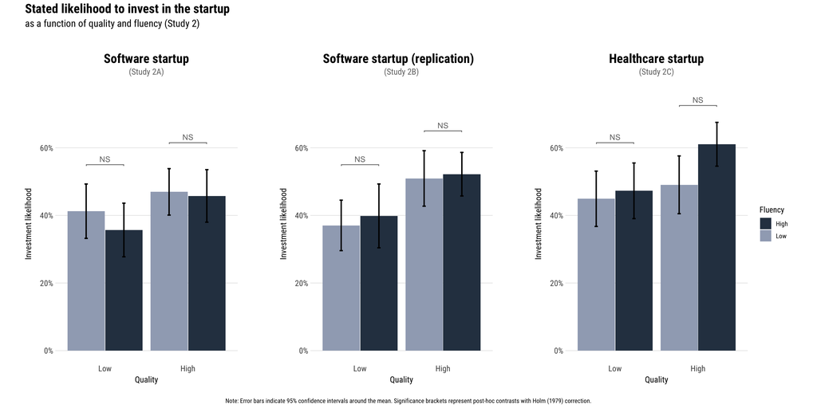

Figure 1: Stated likelihood to invest by visual fluency and substantive quality

```r
# Helper functions and aesthetics
#
# pval function
pval <- function(p, stars = TRUE){
  if(stars){
    if(p < .001) return("***")
    if(p < .01) return("**")
    if(p < .05) return("*")
    if(p >= .05) return("NS")
  } else{
    scales::pvalue(p, prefix = c("p < ", "p = ", "p > "))
  }
}
# aesthetics
#
# define colors
blue_main <- "#297FB8"
blue_dark <- "#2D3E50"
blue_light <- "#A0ABBF"
# theme settings
my_style <- list(hrbrthemes::theme_ipsum_rc(),
                 scale_fill_manual(values=c(blue_light, blue_dark)))
my_theme <- theme(panel.grid.major.x = element_blank(),
        panel.grid.minor = element_blank(),
        plot.title = element_text(hjust = .5),
        axis.title.y = element_text(size = 12, hjust = .5, margin = margin(t = 0, r = 10, b = 0, l = 0)),
        axis.title.x = element_text(size = 12, hjust = .5, margin = margin(t = 5, r = 0, b = 0, l = 0)),
        )
# set up titles, axis names etc.
my_labs <- labs(
  x = "Quality",
  shape='Fluency'
)


# figure: software startup
#
# data prep
#
# for convenience and to not interfere with later code, we work on a copy of
# the data
d_soft <- d_sw
# convert fluency and quality to factor vars
d_soft$fluency <- factor(d_soft$fluency, levels = c("low", "high"), labels = c("Low", "High"))
d_soft$quality <- factor(d_soft$quality, levels = c("low", "high"), labels = c("Low", "High"))

# create dataset for post-hoc contrasts
# --Note: We create a special dataset since we need to change the reference
#         level of the factor variables before switching to effect coding to
#         keep the direction of the effects as intended
d_soft_analysis <- d_soft
d_soft_analysis$fluency <- relevel(d_soft_analysis$fluency, ref = 2)
d_soft_analysis$quality <- relevel(d_soft_analysis$quality, ref = 2)
# switch to effect coding
contrasts(d_soft_analysis$fluency) <- contr.sum # High = 1, Low = -1
contrasts(d_soft_analysis$quality) <- contr.sum

# FIGURE FOR INVESTMENT LIKELIHOOD
#
# post-hoc contrasts (using Holm's correction) via the `emmeans` package
pairs(emmeans::emmeans(lm(invest_prob ~ fluency * quality, d_soft_analysis),
                       ~ quality * fluency), adjust = "holm") |>
  broom::tidy() |> select(adj.p.value) |> pull() -> temp

# contrast: low quality: high vs. low fluency
p1 <- temp[5]
# contrast: high quality: high vs. low fluency
p2 <- temp[2]

# plot
invest_1 <- ggplot(d_soft, aes(x=quality, y=invest_prob, fill=fluency)) +
  stat_summary(fun = "mean", geom="bar", position=position_dodge(.91)) +
  stat_summary(fun.data = mean_cl_normal, fun.args=list(mult=2), geom="errorbar", width=.08, linewidth=.9,
               position=position_dodge(.91)) +
  my_style + my_theme + my_labs +
  labs(y="Investment likelihood",
       title = "<b>Software startup</b><br>
       <span style='color:gray45; font-size:12pt'>(Study 2A)</span>",
       fill = "Fluency") +
  theme(plot.title = element_markdown(face = "plain")) +
  coord_cartesian(ylim=c(0, 75)) +
  scale_y_continuous(labels = scales::label_percent(scale = 1)) +
  guides(fill = guide_legend(reverse=TRUE)) +
  geom_signif(
    # p1
    xmin = c(0.775), xmax = c(1.225),
    y_position = 55,
    tip_length = .003,
    annotations = pval(p1),
    color = "gray45",
    vjust = .0
    ) +
  geom_signif(
    # p2
    xmin = c(1.775), xmax = c(2.225),
    y_position = 61.5,
    tip_length = .003,
    annotations = pval(p2),
    color = "gray45",
    vjust = .0
  )


# figure: software startup (replication)
#
# data prep
#
# for convenience and to not interfere with later code, we work on a copy of
# the data
d_soft_rep <- d_sw_repl
# convert fluency and quality to factor vars
d_soft_rep$fluency <- factor(d_soft_rep$fluency, levels = c("low", "high"), labels = c("Low", "High"))
d_soft_rep$quality <- factor(d_soft_rep$quality, levels = c("low", "high"), labels = c("Low", "High"))

# create dataset for post-hoc contrasts
# --Note: We create a special dataset since we need to change the reference
#         level of the factor variables before switching to effect coding to
#         keep the direction of the effects as intended
d_soft_rep_analysis <- d_soft_rep
d_soft_rep_analysis$fluency <- relevel(d_soft_rep_analysis$fluency, ref = 2)
d_soft_rep_analysis$quality <- relevel(d_soft_rep_analysis$quality, ref = 2)
# switch to effect coding
contrasts(d_soft_rep_analysis$fluency) <- contr.sum # High = 1, Low = -1
contrasts(d_soft_rep_analysis$quality) <- contr.sum

# FIGURE FOR INVESTMENT LIKELIHOOD
#
# post-hoc contrasts (using Holm's correction) via the `emmeans` package
pairs(emmeans::emmeans(lm(invest_prob ~ fluency * quality, d_soft_rep_analysis),
                       ~ quality * fluency), adjust = "holm") |>
  broom::tidy() |> select(adj.p.value) |> pull() -> temp

# contrast: low quality: high vs. low fluency
p1 <- temp[5]
# contrast: high quality: high vs. low fluency
p2 <- temp[2]

# plot
invest_2 <- ggplot(d_soft_rep, aes(x=quality, y=invest_prob, fill=fluency)) +
  stat_summary(fun = "mean", geom="bar", position=position_dodge(.91)) +
  stat_summary(fun.data = mean_cl_normal, fun.args=list(mult=2), geom="errorbar", width=.08, linewidth=.9,
               position=position_dodge(.91)) +
  my_style + my_theme + my_labs +
  labs(y="Investment likelihood",
       title = "<b>Software startup (replication)</b>
       <br><span style='color:gray45; font-size:12pt'>(Study 2B)</span>",
       fill = "Fluency") +
  theme(plot.title = element_markdown(face = "plain")) +
  coord_cartesian(ylim=c(0, 75)) +
  scale_y_continuous(labels = scales::label_percent(scale = 1)) +
  guides(fill = guide_legend(reverse=TRUE)) +
  geom_signif(
    # p1
    xmin = c(0.775), xmax = c(1.225),
    y_position = 55,
    tip_length = .003,
    annotations = pval(p1),
    color = "gray45",
    vjust = .0
    ) +
  geom_signif(
    # p2
    xmin = c(1.775), xmax = c(2.225),
    y_position = c(65),
    tip_length = .003,
    annotations = pval(p2),
    color = "gray45",
    vjust = .0
  )



# figure: healthcare startup
#
# data prep
#
# for convenience and to not interfere with later code, we work on a copy of
# the data
d_health <- d_hc
# convert fluency and quality to factor vars
d_health$fluency <- factor(d_health$fluency, levels = c("low", "high"), labels = c("Low", "High"))
d_health$quality <- factor(d_health$quality, levels = c("low", "high"), labels = c("Low", "High"))

# create dataset for post-hoc contrasts
# --Note: We create a special dataset since we need to change the reference
#         level of the factor variables before switching to effect coding to
#         keep the direction of the effects as intended
d_health_analysis <- d_health
d_health_analysis$fluency <- relevel(d_health_analysis$fluency, ref = 2)
d_health_analysis$quality <- relevel(d_health_analysis$quality, ref = 2)
# switch to effect coding
contrasts(d_health_analysis$fluency) <- contr.sum # High = 1, Low = -1
contrasts(d_health_analysis$quality) <- contr.sum

# FIGURE FOR INVESTMENT LIKELIHOOD
#
# post-hoc contrasts (using Holm's correction) via the `emmeans` package
pairs(emmeans::emmeans(lm(invest_prob ~ fluency * quality, d_health_analysis),
                       ~ quality * fluency), adjust = "holm") |>
  broom::tidy() |> select(adj.p.value) |> pull() -> temp

# contrast: low quality: high vs. low fluency
p1 <- temp[5]
# contrast: high quality: high vs. low fluency
p2 <- temp[2]

# plot
invest_3 <- ggplot(d_health, aes(x=quality, y=invest_prob, fill=fluency)) +
  stat_summary(fun = "mean", geom="bar", position=position_dodge(.91)) +
  stat_summary(fun.data = mean_cl_normal, fun.args=list(mult=2), geom="errorbar", width=.08, linewidth=.9,
               position=position_dodge(.91)) +
  my_style + my_theme + my_labs +
  labs(y="Investment likelihood",
       title = "<b>Healthcare startup</b><br>
       <span style='color:gray45; font-size:12pt'>(Study 2C)</span>",
       fill = "Fluency") +
  theme(plot.title = element_markdown(face = "plain")) +
  coord_cartesian(ylim=c(0, 75)) +
  scale_y_continuous(labels = scales::label_percent(scale = 1)) +
  guides(fill = guide_legend(reverse=TRUE)) +
  geom_signif(
    # p1
    xmin = c(0.775), xmax = c(1.225),
    y_position = 61.5,
    tip_length = .003,
    annotations = pval(p1),
    color = "gray45",
    vjust = .0
    ) +
  geom_signif(
    # p2
    xmin = c(1.775), xmax = c(2.225),
    y_position = c(72.5),
    tip_length = .003,
    annotations = pval(p2),
    color = "gray45",
    vjust = .0
  )



# final (combined) figure
invest_1 + invest_2 + invest_3 + plot_layout(guides = 'collect') +
  plot_annotation(
  title = "<b>Stated likelihood to invest in the startup</b>",
  subtitle = "as a function of quality and fluency (Study 2)",
  caption = "Note: Error bars indicate 95% confidence intervals around the mean. Significance brackets represent post-hoc contrasts with Holm (1979) correction.",
  # tag_levels = 'A'
) & theme(
  plot.title = element_markdown(size = 18, family = "Roboto Condensed", face = "plain"),
  plot.subtitle = element_text(size = 14, family = "Roboto Condensed"),
  plot.caption = element_text(hjust=.5, family = "Roboto Condensed", margin = margin(t = -10, r = 0, b = 0, l = 0)),
)
```